# Dataset structure

What this project actually contains, and how the pieces fit together — the experimental design, the reference genomes, and the way a bacterial and a plant genome are combined into one index so that a single alignment pass can separate the two organisms.

This is the companion to `01_results_overview.ipynb`, which covers what came *out* of the pipeline. Read this one first if you are new to the dataset.

```python
import re
import sys
from pathlib import Path

import numpy as np
import pandas as pd
import matplotlib as mpl
import matplotlib.pyplot as plt

ROOT = Path.cwd()
while not (ROOT / "samples.tsv").exists() and ROOT != ROOT.parent:
    ROOT = ROOT.parent
sys.path.insert(0, str(ROOT / "notebooks"))

import gallrna_viz as gv                      # shared palette + helpers
from gallrna_viz import (SERIES, SURFACE, INK, INK2, GRID, SEQ, AGRO, PLANT,
                         HOST_COLOR, HOST_ORDER, STRAIN_COLOR, REPL, REPL_LABEL,
                         REPL_COLOR, box, arrow, blank, clean, note, barh, save)
gv.use_theme()

meta = gv.load_meta()
print("project root:", ROOT, "|", len(meta), "samples")
```

```
project root: /home/andrew.dickson/gallrna | 14 samples
```

```python
# The Makefile is the single source of truth for which genome each sample uses,
# so parse it rather than restating the mapping here.
mk = (ROOT / "Makefile").read_text()
ACC     = dict(re.findall(r"^ACC_(\w+)\s*:?=\s*(\S+)", mk, re.M))
HOSTOF  = dict(re.findall(r"^HOST_([\w.-]+)\s*=\s*(\S+)", mk, re.M))
ANNOT   = re.search(r"^ANNOT_HOSTS\s*:?=\s*(.*)$", mk, re.M).group(1).split()
HOSTS   = re.search(r"^HOSTS\s*:?=\s*(.*)$", mk, re.M).group(1).split()

meta["ref_genome"] = meta.index.map(HOSTOF)
meta["strain_geno"] = meta["strain"] + " " + meta["genotype"]
pretty = lambda g: g.replace("_", " ").replace(" proxy", " (proxy)").capitalize()

pd.DataFrame({"accession": pd.Series(ACC), "annotated": pd.Series({h: h in ANNOT for h in HOSTS}),
              "samples": pd.Series({h: (meta.ref_genome == h).sum() for h in HOSTS})})
```

|  | accession | annotated | samples |
| --- | --- | --- | --- |
| euonymus_japonicus_proxy | GCA_963580455.1 | False | 4 |
| citrus_sinensis | GCF_022201045.2 | True | 5 |
| brassica_juncea | GCA_018703725.1 | False | 2 |
| carica_papaya | GCF_000150535.2 | True | 1 |
| poncirus_trifoliata | GCA_018350135.1 | False | 0 |
| solanum_lycopersicum | GCF_036512215.1 | True | 2 |

## 1. The experiment

Fourteen galls. Two *Agrobacterium* strains (1416 and 29), three genotypes — wild type plus two 1416 mutants, G-19 and G-30 — across seven host plantings, with gall ages spanning 26 to 635 days.

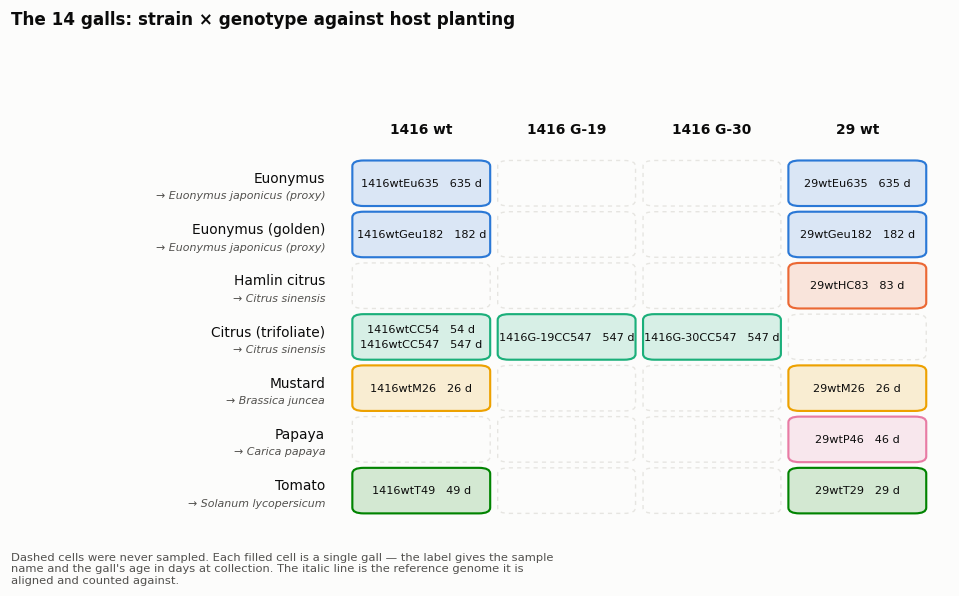

```python
ROWS = ["Euonymus", "Euonymus (golden)", "Hamlin citrus", "Citrus (trifoliate)",
        "Mustard", "Papaya", "Tomato"]
COLS = ["1416 wt", "1416 G-19", "1416 G-30", "29 wt"]

fig, ax = plt.subplots(figsize=(11, 5.6))
blank(ax)
nx, ny = len(COLS), len(ROWS)
cw, ch = 0.155, 0.108
x0, y0 = 0.36, 0.055

for j, c in enumerate(COLS):
    ax.text(x0 + (j + 0.5) * cw, y0 + ny * ch + 0.045, c, ha="center", va="bottom",
            fontsize=9, weight="semibold", color=INK)
for i, r in enumerate(ROWS):
    y = y0 + (ny - 1 - i) * ch
    sub = meta[meta.host_common == r]
    ax.text(x0 - 0.025, y + ch * 0.60, r, ha="right", va="center", fontsize=9, color=INK)
    if len(sub):
        ax.text(x0 - 0.025, y + ch * 0.26, "→ " + pretty(sub.ref_genome.iloc[0]),
                ha="right", va="center", fontsize=7.2, color=INK2, style="italic")
    for j, c in enumerate(COLS):
        cell = sub[sub.strain_geno == c]
        x = x0 + j * cw
        filled = len(cell) > 0
        colour = HOST_COLOR[sub.host_species.iloc[0]] if filled else None
        ax.add_patch(mpl.patches.FancyBboxPatch(
            (x + 0.004, y + 0.006), cw - 0.008, ch - 0.012,
            boxstyle="round,pad=0,rounding_size=0.012",
            facecolor=mpl.colors.to_rgba(colour, 0.16) if filled else SURFACE,
            edgecolor=colour if filled else GRID,
            linewidth=1.4 if filled else 0.9, linestyle="-" if filled else (0, (3, 3)),
            transform=ax.transAxes, clip_on=False))
        if filled:
            txt = "\n".join(f"{s}   {int(a)} d" for s, a in
                            zip(cell.index, cell.gall_age_days))
            ax.text(x + cw / 2, y + ch / 2, txt, ha="center", va="center",
                    fontsize=7.4, color=INK, linespacing=1.6)

ax.set_title("The 14 galls: strain × genotype against host planting", y=1.06)
note(ax, "Dashed cells were never sampled. Each filled cell is a single gall — the label gives the sample\n"
         "name and the gall's age in days at collection. The italic line is the reference genome it is\n"
         "aligned and counted against.", y=-0.02)
save(fig, "20_design_matrix"); plt.show()
```

```python
meta[["strain", "genotype", "host_common", "host_species", "ref_genome",
      "gall_age_days", "gall_mass_g", "source_lab"]]
```

| sample | strain | genotype | host_common | host_species | ref_genome | gall_age_days | gall_mass_g | source_lab |
| --- | --- | --- | --- | --- | --- | --- | --- | --- |
| 1416wtGeu182 | 1416 | wt | Euonymus (golden) | Euonymus japonicus | euonymus_japonicus_proxy | 182 | 9.8 | Shatters |
| 1416wtEu635 | 1416 | wt | Euonymus | Euonymus japonicus | euonymus_japonicus_proxy | 635 | 25.0 | Shatters |
| 29wtGeu182 | 29 | wt | Euonymus (golden) | Euonymus japonicus | euonymus_japonicus_proxy | 182 | 4.0 | Shatters |
| 29wtEu635 | 29 | wt | Euonymus | Euonymus japonicus | euonymus_japonicus_proxy | 635 | 24.3 | Shatters |
| 29wtHC83 | 29 | wt | Hamlin citrus | Citrus sinensis | citrus_sinensis | 83 | 0.9 | Shatters |
| 1416wtCC54 | 1416 | wt | Citrus (trifoliate) | Poncirus trifoliata | citrus_sinensis | 54 | 1.0 | Thomson |
| 1416wtCC547 | 1416 | wt | Citrus (trifoliate) | Poncirus trifoliata | citrus_sinensis | 547 | 1.0 | Thomson |
| 1416G-19CC547 | 1416 | G-19 | Citrus (trifoliate) | Poncirus trifoliata | citrus_sinensis | 547 | 1.0 | Thomson |
| 1416G-30CC547 | 1416 | G-30 | Citrus (trifoliate) | Poncirus trifoliata | citrus_sinensis | 547 | 1.0 | Thomson |
| 1416wtM26 | 1416 | wt | Mustard | Brassica juncea | brassica_juncea | 26 | 4.8 | Shatters |
| 29wtM26 | 29 | wt | Mustard | Brassica juncea | brassica_juncea | 26 | 11.3 | Shatters |
| 29wtP46 | 29 | wt | Papaya | Carica papaya | carica_papaya | 46 | 2.5 | Shatters |
| 1416wtT49 | 1416 | wt | Tomato | Solanum lycopersicum | solanum_lycopersicum | 49 | 1.0 | Thomson |
| 29wtT29 | 29 | wt | Tomato | Solanum lycopersicum | solanum_lycopersicum | 29 | 1.0 | Thomson |

## 2. The reference genomes

Eight genomes are involved: two *Agrobacterium* strains and six plant assemblies. They differ enormously in size — a plant host genome is 50 to 160 times the bacterium — and only three of the six plants carry gene models.

Two substitutions are worth keeping in mind, both forced by what exists publicly:

- **Euonymus** galls are aligned to *E. europaeus* (`GCA_963580455.1`), a congener, because there is no *E. japonicus* assembly.
- **Citrus (trifoliate)** galls are counted on *C. sinensis* — *Poncirus trifoliata* has an assembly but no annotation. That genome was downloaded and indexed, then dropped from the run.

```python
# Sizes come from the alignment indexes themselves (idxstats), so they describe
# exactly what was searched rather than what a datasheet claims.
host_size, agro_size = {}, {}
for s in meta.index:
    d = gv.load_idxstats(s)
    a, p = d[d.ref.str.startswith("agro_")], d[~d.ref.str.startswith("agro_")]
    host_size.setdefault(meta.loc[s, "ref_genome"], (p.length.sum(), len(p)))
    agro_size.setdefault(f"strain_{meta.loc[s, 'strain']}", (a.length.sum(), len(a)))

# Poncirus is in no index that was aligned against, so measure its FASTA directly.
pon = ROOT / "references/plant_host/poncirus_trifoliata/poncirus_trifoliata.fasta"
if "poncirus_trifoliata" not in host_size and pon.exists():
    L = n = 0
    with open(pon) as fh:
        for line in fh:
            if line.startswith(">"):
                n += 1
            else:
                L += len(line.strip())
    host_size["poncirus_trifoliata"] = (L, n)

def gene_count(gff):
    p = Path(gff)
    if not p.exists():
        return np.nan
    ids = {ln.split("ID=")[1].split(";")[0]
           for ln in p.read_text().splitlines() if "\tgene\t" in ln and "ID=" in ln}
    return len(ids)

rows = []
for k, (L, n) in agro_size.items():
    rows.append(dict(reference=k, kind="Agrobacterium", accession="collaborator assembly",
                     size_mb=L / 1e6, contigs=n,
                     genes=gene_count(ROOT / f"references/agrobacterium/{k}/{k}.gff3"),
                     samples=(("strain_" + meta.strain) == k).sum()))
for h in HOSTS:
    L, n = host_size.get(h, (np.nan, np.nan))
    rows.append(dict(reference=h, kind="plant host", accession=ACC.get(h, ""),
                     size_mb=L / 1e6, contigs=n,
                     genes=gene_count(ROOT / f"references/plant_host/{h}/{h}.gff3"),
                     samples=(meta.ref_genome == h).sum()))
refs = pd.DataFrame(rows).set_index("reference")
refs.round(2)
```

| reference | kind | accession | size_mb | contigs | genes | samples |
| --- | --- | --- | --- | --- | --- | --- |
| strain_1416 | Agrobacterium | collaborator assembly | 5.86 | 5 | 5758.0 | 8 |
| strain_29 | Agrobacterium | collaborator assembly | 5.84 | 5 | 5836.0 | 6 |
| euonymus_japonicus_proxy | plant host | GCA_963580455.1 | 443.51 | 33 | NaN | 4 |
| citrus_sinensis | plant host | GCF_022201045.2 | 299.78 | 11 | 28080.0 | 5 |
| brassica_juncea | plant host | GCA_018703725.1 | 933.50 | 1544 | NaN | 2 |
| carica_papaya | plant host | GCF_000150535.2 | 370.42 | 17766 | 20000.0 | 1 |
| poncirus_trifoliata | plant host | GCA_018350135.1 | 303.07 | 485 | NaN | 0 |
| solanum_lycopersicum | plant host | GCF_036512215.1 | 833.38 | 14 | 40019.0 | 2 |

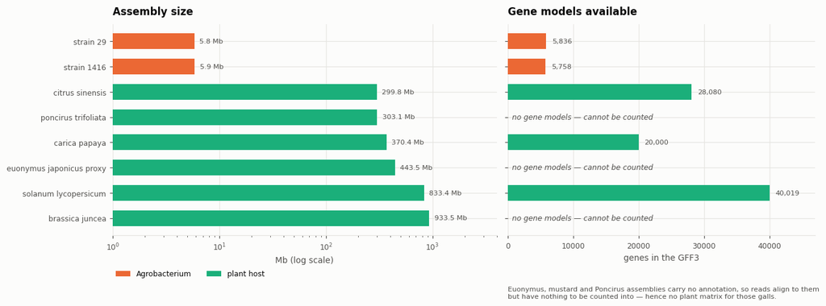

```python
fig, axes = plt.subplots(1, 2, figsize=(13, 4.8), gridspec_kw={"width_ratios": [1.25, 1]})

ax = axes[0]
r = refs.sort_values("size_mb")
cols = [AGRO if k == "Agrobacterium" else PLANT for k in r.kind]
ax.set_xscale("log")
barh(ax, [x.replace("_", " ") for x in r.index], r.size_mb, cols, "{:,.1f} Mb", log=True)
ax.set_xlim(1, 4e3)
ax.set_title("Assembly size")
ax.set_xlabel("Mb (log scale)")
ax.legend(handles=[mpl.patches.Patch(facecolor=AGRO, label="Agrobacterium"),
                   mpl.patches.Patch(facecolor=PLANT, label="plant host")],
          loc="upper left", bbox_to_anchor=(0, -0.15), ncols=2, borderaxespad=0)

ax = axes[1]
ann = r.assign(has_genes=r.genes.notna())
y = np.arange(len(ann))
ax.barh(y, ann.genes.fillna(0), height=0.62,
        color=[AGRO if k == "Agrobacterium" else PLANT for k in ann.kind])
ax.set_yticks(y, [""] * len(ann))
ax.invert_yaxis()
for yi, (g, name) in enumerate(zip(ann.genes, ann.index)):
    if np.isnan(g):
        ax.text(600, yi, "no gene models — cannot be counted", va="center",
                fontsize=8, color=INK2, style="italic")
    else:
        ax.text(g + 900, yi, f"{int(g):,}", va="center", fontsize=7.5, color=INK2)
ax.set_xlim(0, 47000)
ax.set_title("Gene models available")
ax.set_xlabel("genes in the GFF3")
clean(ax, "x")
note(ax, "Euonymus, mustard and Poncirus assemblies carry no annotation, so reads align to them\n"
         "but have nothing to be counted into — hence no plant matrix for those galls.", y=-0.24)
plt.tight_layout(); save(fig, "21_reference_inventory"); plt.show()
```

### The bacterial side, to scale

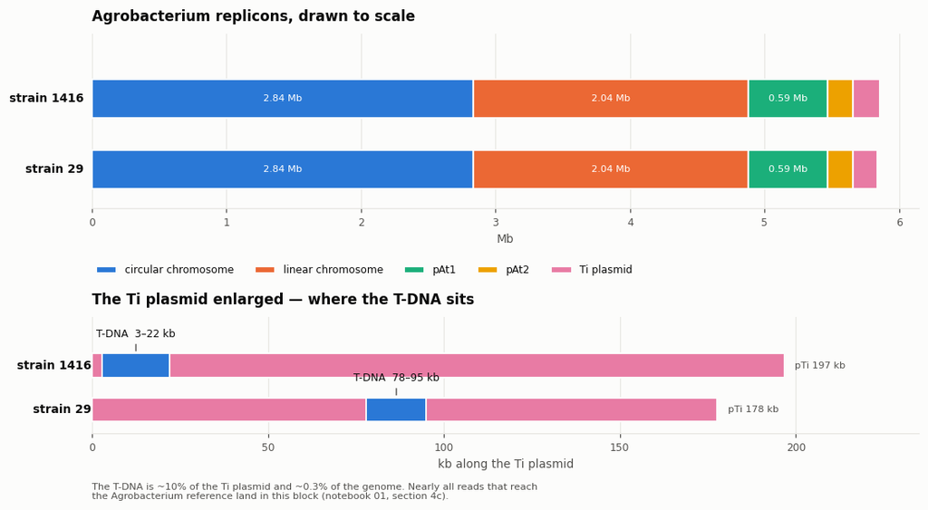

```python
strains = ["1416", "29"]
lens = {}
for st in strains:
    s = meta[meta.strain == st].index[0]
    d = gv.load_idxstats(s)
    d = d[d.ref.str.startswith("agro_")]
    lens[st] = dict(zip(d.ref.str.rsplit("_", n=1).str[-1], d.length))

TDNA = {"1416": (3_000, 22_000), "29": (78_000, 95_000)}   # from the coverage in notebook 01

fig, axes = plt.subplots(2, 1, figsize=(11.5, 5.6),
                         gridspec_kw={"height_ratios": [1.5, 1], "hspace": 0.75})
h = 0.30
ax = axes[0]
for i, st in enumerate(strains):
    y = 1 - i * 0.55
    left = 0.0
    for rep in REPL:
        L = lens[st][rep] / 1e6
        ax.barh(y, L, left=left, height=h, color=REPL_COLOR[rep],
                edgecolor=SURFACE, linewidth=1.4,
                label=REPL_LABEL[rep] if i == 0 else None)
        if L > 0.35:
            ax.text(left + L / 2, y, f"{L:.2f} Mb", ha="center", va="center",
                    fontsize=7.5, color="white")
        left += L
    ax.text(-0.06, y, f"strain {st}", ha="right", va="center", fontsize=9,
            weight="semibold", color=INK)
ax.set_ylim(0.15, 1.5); ax.set_yticks([])
ax.set_xlabel("Mb")
ax.set_title("Agrobacterium replicons, drawn to scale")
clean(ax, "x"); ax.spines["bottom"].set_visible(True)
ax.legend(loc="upper left", bbox_to_anchor=(0, -0.30), ncols=5, borderaxespad=0)

# The Ti plasmid is too small to show the T-DNA in the panel above, so enlarge it.
ax = axes[1]
for i, st in enumerate(strains):
    y = 1 - i * 0.55
    L = lens[st]["pTi"] / 1000
    ax.barh(y, L, height=h, color=REPL_COLOR["pTi"], edgecolor=SURFACE, linewidth=1.4)
    lo, hi = TDNA[st]
    ax.barh(y, (hi - lo) / 1000, left=lo / 1000, height=h, color=SERIES[0],
            edgecolor=SURFACE, linewidth=1.2)
    ax.annotate(f"T-DNA  {lo/1000:.0f}–{hi/1000:.0f} kb", xy=((lo + hi) / 2000, y + h / 2),
                xytext=(0, 13), textcoords="offset points", ha="center", fontsize=8,
                color=INK, arrowprops=dict(arrowstyle="-", color=INK2, linewidth=0.9))
    ax.text(-0.06, y, f"strain {st}", ha="right", va="center", fontsize=9,
            weight="semibold", color=INK)
    ax.text(L + 3, y, f"pTi {L:.0f} kb", va="center", fontsize=7.5, color=INK2)
ax.set_ylim(0.15, 1.6); ax.set_yticks([]); ax.set_xlim(0, 235)
ax.set_xlabel("kb along the Ti plasmid")
ax.set_title("The Ti plasmid enlarged — where the T-DNA sits")
clean(ax, "x"); ax.spines["bottom"].set_visible(True)
note(ax, "The T-DNA is ~10% of the Ti plasmid and ~0.3% of the genome. Nearly all reads that reach\n"
         "the Agrobacterium reference land in this block (notebook 01, section 4c).", y=-0.42)
plt.tight_layout(); save(fig, "22_replicon_map"); plt.show()
```

## 3. How the two genomes are combined

The pipeline does **not** align each sample twice. Instead it concatenates the bacterial and plant references into a single FASTA, builds one HISAT2 index from it, and aligns each sample once against that.

The reason is competitive assignment. With two separate alignments, a read from a conserved region could map acceptably to both genomes and be counted twice — once as plant, once as bacterium. With both genomes in one index, HISAT2 scores every read against all sequences at once and reports the best hit, so each read lands on one organism or neither.

Contig names carry the split: everything from the bacterium is prefixed `agro_<strain>_`, so the two organisms can be separated afterwards by name alone.

[figure not shown]

```python
fig, axes = plt.subplots(2, 1, figsize=(13, 8), gridspec_kw={"hspace": 0.34})

# ---- panel A: building one index per strain x host ------------------------
ax = blank(axes[0])
ax.set_title("A. Build one combined reference for each strain × host pairing", y=1.0)
box(ax, 0.01, 0.56, 0.21, 0.30,
    "Agrobacterium  strain 1416\n5.86 Mb · 5 replicons\ncontigs: agro_1416_circ, …",
    face=mpl.colors.to_rgba(AGRO, 0.13), edge=AGRO)
box(ax, 0.01, 0.10, 0.21, 0.30,
    "Host genome  Citrus sinensis\n299.8 Mb · 11 chromosomes\ncontigs: CM031925.1, …",
    face=mpl.colors.to_rgba(PLANT, 0.13), edge=PLANT)
box(ax, 0.31, 0.33, 0.22, 0.30,
    "concatenate\n\nstrain_1416__citrus_sinensis\n.fasta  +  .gff3", face=SURFACE)
box(ax, 0.62, 0.33, 0.16, 0.30, "hisat2-build\n\none index\nper pairing", face=SURFACE)
box(ax, 0.85, 0.33, 0.14, 0.30, "10 indexes\nbuilt\n(9 used)",
    face=mpl.colors.to_rgba(SERIES[0], 0.13), edge=SERIES[0])
arrow(ax, (0.22, 0.71), (0.31, 0.55))
arrow(ax, (0.22, 0.25), (0.31, 0.41))
arrow(ax, (0.53, 0.48), (0.62, 0.48))
arrow(ax, (0.78, 0.48), (0.85, 0.48))
ax.text(0.42, 0.24, "bacterial contigs are renamed with an\n`agro_<strain>_` prefix at this step",
        ha="center", fontsize=7.8, color=INK2, style="italic")

# ---- panel B: one alignment pass per sample, then the split ---------------
ax = blank(axes[1])
ax.set_title("B. Align each sample once, then split the result by contig name", y=1.0)
box(ax, 0.01, 0.36, 0.15, 0.28, "trimmed reads\n\nsample FASTQ\nR1 + R2", face=SURFACE)
box(ax, 0.21, 0.36, 0.17, 0.28,
    "hisat2\n\none pass against the\ncombined index", face=SURFACE)
box(ax, 0.43, 0.36, 0.13, 0.28, "sorted BAM\n\nbest hit per\nread pair",
    face=mpl.colors.to_rgba(SERIES[0], 0.13), edge=SERIES[0])
box(ax, 0.64, 0.62, 0.34, 0.30,
    "samtools idxstats  →  reads per contig\nprefix agro_*  ⇒  bacterial   ·   rest  ⇒  plant\n"
    "logs/mapping_fractions.tsv", face=SURFACE)
box(ax, 0.64, 0.06, 0.34, 0.30,
    "featureCounts on the combined GFF3\nsplit by contig  ⇒  agro_strain_*.tsv\n"
    "and plant_<species>.tsv", face=SURFACE)
arrow(ax, (0.16, 0.50), (0.21, 0.50))
arrow(ax, (0.38, 0.50), (0.43, 0.50))
arrow(ax, (0.56, 0.55), (0.64, 0.72))
arrow(ax, (0.56, 0.45), (0.64, 0.26))
ax.text(0.295, 0.26, "a read that fits both organisms is\nassigned once, to its better match",
        ha="center", fontsize=7.8, color=INK2, style="italic")
save(fig, "23_combined_reference"); plt.show()
```

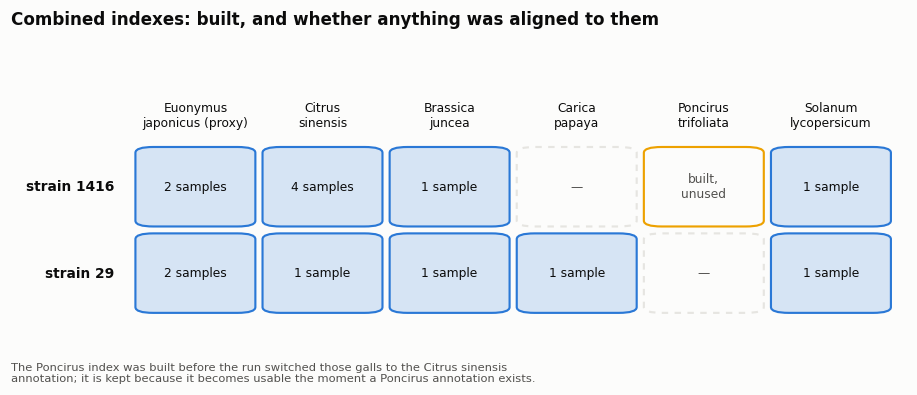

```python
# Which pairings were actually built, and which are in use.
built = {p.name.replace(".hisat2.ok", "")
         for p in (ROOT / "references/combined").glob("*.hisat2.ok")}
used = {f"strain_{r.strain}__{r.ref_genome}" for _, r in meta.iterrows()}

fig, ax = plt.subplots(figsize=(10.5, 3.4))
blank(ax)
cw, ch, x0, y0 = 0.142, 0.30, 0.135, 0.18
for j, h in enumerate(HOSTS):
    ax.text(x0 + (j + 0.5) * cw, y0 + 2 * ch + 0.05, pretty(h).replace(" ", "\n", 1),
            ha="center", va="bottom", fontsize=8, color=INK)
for i, st in enumerate(["1416", "29"]):
    y = y0 + (1 - i) * ch
    ax.text(x0 - 0.02, y + ch / 2, f"strain {st}", ha="right", va="center",
            fontsize=9, weight="semibold", color=INK)
    for j, h in enumerate(HOSTS):
        combo = f"strain_{st}__{h}"
        n = sum((meta.strain == st) & (meta.ref_genome == h))
        if combo in used:
            face, edge, txt, tc = mpl.colors.to_rgba(SERIES[0], 0.18), SERIES[0], f"{n} sample{'s' * (n > 1)}", INK
        elif combo in built:
            face, edge, txt, tc = SURFACE, SERIES[3], "built,\nunused", INK2
        else:
            face, edge, txt, tc = SURFACE, GRID, "—", INK2
        ax.add_patch(mpl.patches.FancyBboxPatch(
            (x0 + j * cw + 0.004, y + 0.012), cw - 0.008, ch - 0.024,
            boxstyle="round,pad=0,rounding_size=0.02", facecolor=face, edgecolor=edge,
            linewidth=1.4, linestyle="-" if combo in built else (0, (3, 3)),
            transform=ax.transAxes, clip_on=False))
        ax.text(x0 + (j + 0.5) * cw, y + ch / 2, txt, ha="center", va="center",
                fontsize=8, color=tc)
ax.set_title("Combined indexes: built, and whether anything was aligned to them", y=1.14)
note(ax, "The Poncirus index was built before the run switched those galls to the Citrus sinensis\n"
         "annotation; it is kept because it becomes usable the moment a Poncirus annotation exists.",
     y=0.02)
save(fig, "24_combos"); plt.show()
```